# Przypadek III

Przykłady modeli LR do rozdziału *Iloraz wiarygodności jako rekomendowane narzędzie weryfikacji hipotezy o wspólnym pochodzeniu dowodów rzeczowych

## Obliczenia LR w modelach hybrydowych dla kilku par próbek dowodowych i porównawczych

Obliczenia LR w modelach hybrydowych dla kilku par próbek dowodowych i porównawczych można przeprowadzić jednocześnie za pomocą skryptu hybridLR_comparison_casework_code.R, dostępnego w folderze III. Egzekucja (wywołanie) tego kodu wymaga kilku minut w zależności od mocy obliczeniowej komputera.

Analizowane próbki stanowiące podstawę rozważań w hybrydowych modelach LR, opisane są przez fragmenty widm Ramana w zakresie ok. 650-950 cm<sup>-1</sup>. Każda próbka opisana jest więc przez wektor o długości równej 300. Taka liczba zmiennych (p) w porównaniu do liczby próbek w bazie danych (M=20) skłania nas do zastosowania hybrydowych modeli LR. Wszystkie widma po przeprowadzeniu tzw. preprocessingu obejmującego korekcję linii bazowej, a także normalizację, zebrane w bazie danych nałożono na siebie uzyskując poniższy rysunek:

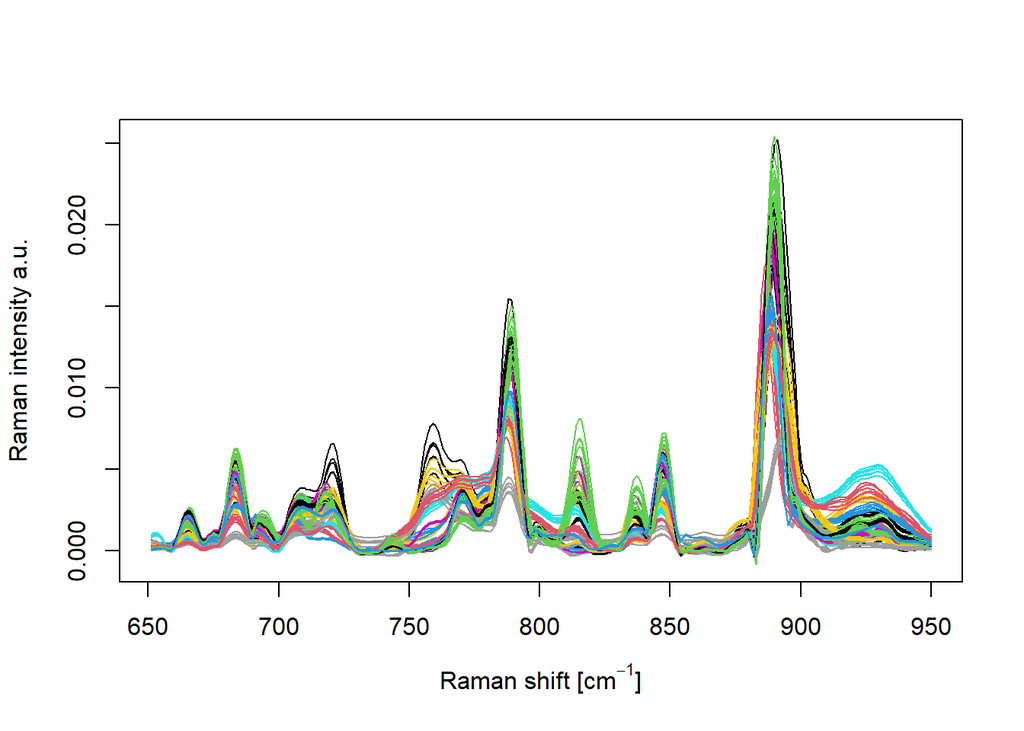

Poniżej krok po kroku przedstawiony został sposób policzenia wartości LR w hybrydowym modelu LR, gdzie za pomocą metody rMANOVA redukuje się liczbę zmiennych, jednocześnie maksymalizując stosunek zmienności między- do wewnątrzobiektowej. LR obliczany jest więc na podstawie nowej zmiennej, utworzonej poprzez zrzutowanie danych oryginalnych na pierwszy kierunek wyznaczony z dekompozycji rMANOVA.

Poniżej kod ten rozbity jest na kilka istotnych fragmentów. Wiele z jego fragmentów znanych jest już z poprzednich przykładów dla klasycznych modeli LR (Przypadek I i II). Wszelkie modyfikacje związane są z tworzeniem zbiorów uczących oraz testowych przeprowadzonym zgodnie z procedurą opisaną w podrozdziale *Konstrukcja zbiorów uczących i testowych->Podział na zbiory uczące i testowe, gdy m<p*.

Na etapie ładowania pakietów oraz funkcji dodatkowo pojawia się funkcja rMANOVA_general_function() zapisana w pliku rMANOVA_general_function.R służąca do utworzenia nowych zmiennych na podstawie rMANOVA.

```r
source("../BW_function.R")
source("../LR_Nor_comparison_function.R")
source("../LR_KDE_comparison_function.R")
source("../rMANOVA_general_function.R")

if (!require("mvtnorm")) install.packages("mvtnorm")
```

Ładowanie danych z plików dla bazy danych (population), próbek dowodowych (data.recovered) i porównawczych (data.control). Dodatkowo wprowadzamy zmienną data.analysed, która będzie przechowywać oryginalną bazę danych, podczas gdy zmienna population zmienia się w zależności od porównywanych próbek.

```r
population = read.table("../spectra_database.txt", header = TRUE)
data.analysed = population
data.recovered = read.table("../spectra_recovered.txt", header = TRUE)
data.control = read.table("../spectra_control.txt", header = TRUE)
```

Liczbę próbek zgromadzonych w bazie danych (M=m), liczbę próbek porównawczych (m.control) oraz dowodowych (m.recovered), a także liczbę pomiarów dla próbek z bazy danych (n.all) oraz dla próbek dowodowych (n.recovered) oraz porównawczych (n.control) można uzyskać wpisując:

```r
M = m = length(unique(data.analysed$Name))
n.all=length(unique(data.analysed$Piece))
m.control = length(unique(data.control$Name))
m.recovered = length(unique(data.recovered$Name))
n.control=length(unique(data.control$Piece))
n.recovered=length(unique(data.recovered$Piece))

print(paste("liczba próbek w bazie danych = ",M));print(paste("liczba próbek dowodowych = ",m.recovered));print(paste("liczba próbek porównawczych = ",m.control));print(paste("liczba pomiarów dla próbek w bazie danych = ",n.all));print(paste("liczba pomiarów dla próbek dowodowych = ",n.recovered));print(paste("liczba pomiarów dla próbek porównawczych = ",n.control))
```

```
## [1] "liczba próbek w bazie danych =  20"
```

```
## [1] "liczba próbek dowodowych =  2"
```

```
## [1] "liczba próbek porównawczych =  3"
```

```
## [1] "liczba pomiarów dla próbek w bazie danych =  6"
```

```
## [1] "liczba pomiarów dla próbek dowodowych =  6"
```

```
## [1] "liczba pomiarów dla próbek porównawczych =  6"
```

Ze względu na losowy charakter tworzenia zbiorów uczących oraz testowych, tworzonych zgodnie z procedurą opisaną w podrozdziale *Konstrukcja zbiorów uczących i testowych->Podział na zbiory uczące i testowe, gdy m<p*, obliczenia prowadzi się kilkakrotnie w celu uniknięcia uzyskania zbyt pesymistycznych lub zbyt optymistycznych wyników. Liczba tych iteracji zdefiniowana jest w zmiennej validationSetsNo (tutaj validationSetsNo=5). Kilkukrotne obliczenia realizowane są dzięki pętli przebiegającej po s, iterującej po wartościach od 1 do validationSetsNo.

```r
validationSetsNo = 5
```

Wynikowe macierze (w przypadku założenia rozkładu normalnego output.matrix.Nor i output.matrix.KDE, gdy rozkład modelujemy przez KDE) będą zawierać wszystkie wartości LR dla każdej z par próbek dowodowych i porównawczych, gdzie rzędy odpowiadają próbkom dowodowym, a kolumny porównawczym. Macierze te mają również trzeci wymiar równy założonej maksymalnej liczbie iteracji (validationSetsNo).

```r
output.matrix.Nor = output.matrix.KDE = array(NA,c(m.recovered,m.control,validationSetsNo),dimnames=list(as.character(unique(data.recovered$Name)),as.character(unique(data.control$Name)),1:validationSetsNo))
```

Kolejno dane dla próbek zgromadzonych w bazie danych, jak i próbek dowodowych i porównawczych są dzielone zgodnie z procedurą opisaną w podrozdziale *Konstrukcja zbiorów uczących i testowych->Podział na zbiory uczące i testowe, gdy m<p*, Rys. 1.5. W poniższym fragmencie kodu poszczególne etapy oznaczone zostały za pomocą komentarzy ## zgodnie z notacją zamieszczoną w podrozdziale *Konstrukcja zbiorów uczących i testowych->Podział na zbiory uczące i testowe, gdy m<p* na Rys. 1.5. Każdy ze zbiorów A.1-A.2, y.1.1-y.1.2, y.2.1-y.2.2 powstaje z losowo wybranych trzech spośród sześciu dostępnych pomiarów dla każdej z próbek z bazy danych, próbek dowodowych i próbek porównawczych. Komenda set.seed(s) jest dodana tutaj, by użytkownik uzyskał w przykładzie identyczne rezultaty, mimo, iż generowanie zbiorów testowych i uczących jest losowe. Usunięcie tej komendy (jak w skrypcie hybridLR_comparison_casework_code.R) pozwala na powrót do całkowicie losowej generacji zbiorów.

Kolejne dwie zagnieżdzone pętle przebiegają po każdej próbce porównawczej (i) i dowodowej (j) i realizują obliczenia dla każdej możliwej pary próbek dowodowych i porównawczych. Wewnątrz tych pętli zagnieżdżona jest jeszcze jedna pętla przebiegająca po wszystkich submodelach (v), jakie rozpatrujemy. W przypadku rMANOVA LR liczony jest jedynie na pierwszym, najbardziej istotnym kierunku, stąd też jej zastosowanie jest niewielkie w tym przypadku.

Kolejnym etapem jest utworzenie próbek y.1 i y.2 oraz population zgodnie z założoną procedurą tworzenia zbiorów testowych i uczących opisaną w *Konstrukcja zbiorów uczących i testowych->Podział na zbiory uczące i testowe, gdy m<p*. Ze względu na nieustannie zmieniający się skład bazy danych w każdym porównaniu, konieczne jest obliczenie aktualnej liczby próbek, m oraz liczby ich pomiarów, n.

Kolejno liczymy macierze $\mathbf{W}$ i $\mathbf{B}$, średnią dla wszystkich próbek z bazy danych (x.mean ($\mathbf{\bar{x}}$)) oraz parametr wygładzający h.

Następnie obliczamy liczbę pomiarów dla próbek y.1 i y.2 (k.1 ($k_1$) i k.2 ($k_2$)) oraz ich średnie (y.mean.1 ($\mathbf{\bar{y}}_1$), y.mean.2 ($\mathbf{\bar{y}}_2$), y.star ($\mathbf{\bar{y}}^{*}$)).

Na podstawie zgromadzonych danych obliczamy wartości LR zakładając rozkład normalny średnich dla próbek w bazie danych (LR.Nor) lub modelując go za pomocą KDE (LR.KDE). Każda obliczona wartość zostaje wpisana do macierzy wynikowych (output.matrix.Nor i output.matrix.KDE).

```r
for (s in 1:validationSetsNo)
{
  tvec = NULL
  for (g in 1:M)
  {set.seed(s);tvec = c(tvec,sample(rep(c(1,2),each=n.all/2)))}

  A.1 = data.analysed[which(tvec == 1),] ##etap 1
  A.1[,"Piece"] = rep(1:(n.all/2),times=M)
  A.2 = data.analysed[which(tvec == 2),] ##etap 1
  A.2[,"Piece"] = rep(1:(n.all/2),times=M)

  tvec = NULL
  for (g in 1:m.control)
  {set.seed(s);tvec = c(tvec,sample(rep(c(1,2),each=n.control/2)))}

  y.2.1 = data.control[which(tvec == 1),] ##etap 2
  y.2.1[,"Piece"] = rep(1:(n.control/2),times=m.control)
  y.2.2 = data.control[which(tvec == 2),] ##etap 2
  y.2.2[,"Piece"] = rep(1:(n.control/2),times=m.control)

  tvec = NULL
  for (g in 1:m.recovered)
  {set.seed(s);tvec = c(tvec,sample(rep(c(1,2),each=n.recovered/2)))}

  y.1.1 = data.recovered[which(tvec == 1),] ##etap 2
  y.1.1[,"Piece"] = rep(1:(n.recovered/2),times=m.recovered)
  y.1.2 = data.recovered[which(tvec == 2),] ##etap 2
  y.1.2[,"Piece"] = rep(1:(n.recovered/2),times=m.recovered)

  for (i in 1:m.control)
  {
    B = rbind(A.1,y.2.1[which(y.2.1$Item==i),]) ##etap 3
    B[,"Name"] = c(A.1[,3],rep("control",times=n.control/2))
    B[,"Item"] = c(rep(1:(M),each=n.all/2),rep(M+1,times=n.control/2))
    B[,"Piece"] = c(rep(1:(n.all/2),times=M),rep(1:(n.control/2),times=1))

    rMANOVA_res = rMANOVA_general_function(data=as.data.frame(B)) ##etap 4
    eigen_vectors = rMANOVA_res$results
    center = rMANOVA_res$center

    for (j in 1:m.recovered)
    {
      A = rbind(A.2,y.2.2[which(y.2.2$Item==i),],y.1.2[which(y.1.2$Item==j),]) ##etap 5
      A[,"Name"] = c(A.2[,1],rep("control",times=n.control/2),rep("recovered",times=n.recovered/2))
      A[,"Item"] = c(rep(1:(M),each=n.all/2),rep(M+1,times=n.control/2),rep(M+2,times=n.recovered/2))
      A[,"Piece"] = c(rep(1:(n.all/2),times=M),rep(1:(n.control/2),times=1),rep(1:(n.recovered/2),times=1))

      meanCentred_test = cbind(A[,c(1:3)],A[,-c(1:3)]-matrix(center,nrow=nrow(A),ncol=ncol(A)-3,byrow=T))
      projections = as.matrix(meanCentred_test[,-c(1:3)])%*%eigen_vectors ##etap 6
      P = cbind(A[,1:3],projections) ##etap 6

      vars = 1

      LR.final.Nor=LR.final.KDE = 1

      for (v in 1:length(vars))
      {
        variables = vars[v]+3
        p = length(variables)

        y.1 = P[which(P$Item==M+2),]
        y.2 = P[which(P$Item==M+1),]

        population = P[which(!P$Item %in% c(M+1,M+2)),]

        n = length(unique(population$Piece))
        m = length(unique(population$Item))

        results.BW = BW(population=population,variables=variables,n=n,m=m)
        W = results.BW$W
        B = results.BW$B

        ifelse(p>1,x.mean<-colMeans(population[,variables]),x.mean<-mean(population[,variables]))

        h = (4/(m*(2*p+1)))^(1/(p+4))

        k.1 = length(y.1$Item)
        k.2 = length(y.2$Item)

        y.mean.1 = matrix(apply(as.matrix(y.1[,variables]), 2, mean), nrow = 1)
        y.mean.2 = matrix(apply(as.matrix(y.2[,variables]), 2, mean), nrow = 1)
        y.star = (k.1*y.mean.1+k.2*y.mean.2)/(k.1+k.2)

        results.LR.Nor = LR.Nor.function(y.mean.1, y.mean.2, y.star, x.mean, W, B, k.1, k.2) ##etap 7
        LR.Nor = results.LR.Nor$LR.Nor

        results.LR.KDE= LR.KDE.function(y.mean.1, y.mean.2, y.star, W, B, h, population, variables, p, k.1, k.2) ##etap 7
        LR.KDE = results.LR.KDE$LR.KDE

        LR.final.Nor=LR.final.Nor*LR.Nor
        LR.final.KDE=LR.final.KDE*LR.KDE
      }
      output.matrix.Nor[j,i,s] = LR.final.Nor
      output.matrix.KDE[j,i,s] = LR.final.KDE
    }
  }
}
```

```r
print(output.matrix.Nor)
```

```
## , , 1
##
##                control_1 control_2    control_3
## recovered_1 1.029537e-24  1.162879 3.720275e+00
## recovered_2 4.961131e-01  3.553342 3.072217e-10
##
## , , 2
##
##                control_1    control_2    control_3
## recovered_1 3.481087e-11 1.171133e-54 2.007139e-22
## recovered_2 1.472263e-01 2.402731e-32 3.153465e-73
##
## , , 3
##
##             control_1    control_2    control_3
## recovered_1  6.466448 4.031096e-13 1.281467e-54
## recovered_2  6.175185 8.156512e-38 2.635191e-52
##
## , , 4
##
##               control_1    control_2    control_3
## recovered_1  0.02970076 2.874386e-34 6.267859e-42
## recovered_2 27.50060252 6.328090e-32 1.857733e-89
##
## , , 5
##
##                 control_1    control_2     control_3
## recovered_1 1.930997e-111 4.345708e-29  3.924920e-44
## recovered_2  7.640665e-02 1.453567e-04 1.332444e-232
```

```r
print(output.matrix.KDE)
```

```
## , , 1
##
##                control_1 control_2    control_3
## recovered_1 9.947943e-25  1.097534 3.822600e+00
## recovered_2 4.210652e-01  3.120729 2.942223e-10
##
## , , 2
##
##                control_1    control_2    control_3
## recovered_1 2.898290e-11 9.741097e-55 2.058270e-22
## recovered_2 1.097565e-01 1.881606e-32 3.113201e-73
##
## , , 3
##
##             control_1    control_2    control_3
## recovered_1  6.439695 3.085496e-13 1.212894e-54
## recovered_2  6.153771 7.176901e-38 2.529717e-52
##
## , , 4
##
##               control_1    control_2    control_3
## recovered_1  0.02520182 2.344385e-34 6.635312e-42
## recovered_2 22.24273317 5.113095e-32 1.812749e-89
##
## , , 5
##
##                 control_1    control_2     control_3
## recovered_1 1.880820e-111 3.712291e-29  4.819851e-44
## recovered_2  6.430149e-02 1.165588e-04 1.423734e-232
```

Uzyskane macierze wynikowe można zapisać do plików hybridLR_comparison_casework_Nor.txt oraz hybridLR_comparison_casework_KDE.txt, które zostaną utworzone przez program i zapisane w folderze, w którym pracujemy.

```r
saveRDS(output.matrix.Nor,file="hybridLR_comparison_casework_Nor.txt")
saveRDS(output.matrix.KDE,file="hybridLR_comparison_casework_KDE.txt")
```

Pliki te można otworzyć za pomocą RStudio:

```r
readRDS("hybridLR_comparison_casework_Nor.txt")
```

```
## , , 1
##
##                control_1 control_2    control_3
## recovered_1 1.029537e-24  1.162879 3.720275e+00
## recovered_2 4.961131e-01  3.553342 3.072217e-10
##
## , , 2
##
##                control_1    control_2    control_3
## recovered_1 3.481087e-11 1.171133e-54 2.007139e-22
## recovered_2 1.472263e-01 2.402731e-32 3.153465e-73
##
## , , 3
##
##             control_1    control_2    control_3
## recovered_1  6.466448 4.031096e-13 1.281467e-54
## recovered_2  6.175185 8.156512e-38 2.635191e-52
##
## , , 4
##
##               control_1    control_2    control_3
## recovered_1  0.02970076 2.874386e-34 6.267859e-42
## recovered_2 27.50060252 6.328090e-32 1.857733e-89
##
## , , 5
##
##                 control_1    control_2     control_3
## recovered_1 1.930997e-111 4.345708e-29  3.924920e-44
## recovered_2  7.640665e-02 1.453567e-04 1.332444e-232
```

```r
readRDS("hybridLR_comparison_casework_KDE.txt")
```

```
## , , 1
##
##                control_1 control_2    control_3
## recovered_1 9.947943e-25  1.097534 3.822600e+00
## recovered_2 4.210652e-01  3.120729 2.942223e-10
##
## , , 2
##
##                control_1    control_2    control_3
## recovered_1 2.898290e-11 9.741097e-55 2.058270e-22
## recovered_2 1.097565e-01 1.881606e-32 3.113201e-73
##
## , , 3
##
##             control_1    control_2    control_3
## recovered_1  6.439695 3.085496e-13 1.212894e-54
## recovered_2  6.153771 7.176901e-38 2.529717e-52
##
## , , 4
##
##               control_1    control_2    control_3
## recovered_1  0.02520182 2.344385e-34 6.635312e-42
## recovered_2 22.24273317 5.113095e-32 1.812749e-89
##
## , , 5
##
##                 control_1    control_2     control_3
## recovered_1 1.880820e-111 3.712291e-29  4.819851e-44
## recovered_2  6.430149e-02 1.165588e-04 1.423734e-232
```

**INTERPRETACJA: W wyniku obliczeń uzyskano wartości LR dla każdej pary próbek dowodowych i porównawczych. Dla każdej pary próbek obliczono LR pięciokrotnie, modelując rozkład średnich dla próbek za pomocą rozkładu normalnego lub KDE. Analizując wartości LR uzyskane dla każdej pary w zależności od sposobu modelowania rozkładu lub numeru iteracji, biegły może dokonać oceny, jak dane dla próbki w parze wspierają poszczególne hipotezy i jak to wsparcie jest stabilne w zależności od sposobu modelowania rozkładu lub losowości tworzenia zbiorów testowych i uczących. Ponadto kluczowym staje się też pytanie, który z modeli jest lepszy, ten oparty o rozkład normalny, czy KDE? W tym przypadku oba modele dają porównywalne rezultaty (odpowiadające sobie wartości LR w obu modelach są zbliżone). W razie rozbieżności bardziej adekwatny powinien okazać się model bazujący na KDE, ponieważ rozkład modelowany empirycznie jest bliższy rzeczywistości niż założony rozkład normalny. Innym sposobem jest też wykorzystanie testów istotości, które pozwalają na ustalenie, czy dane użyte do modelu mogą pochodzić z rozkładu normalnego.**